# PSC RTMB Course

## Introductions

- Paul van Dam-Bates (Fisheries and Oceans Canada)
- PhD Statistics University of St Andrews (Scotland)
- NIMBLE Development Team [here](https://r-nimble.org/)
- Work on computational statistics (e.g. approximate posterior distributions, MCMC methods, efficient matrix exponentiation, and other things)
- R packages `nimbleQuad` and `spbal`

## Why RTMB

- R wrapper for TMB
- Convert R code to C++ for speed
- Automatic Differentiation
- Integrate out random effects (e.g. Laplace)
- Code can run in basic R for checking

## Course Structure

- Can’t code if you don’t understand model
- Focus on understanding a model, then coding it in R
- RTMB is very simple if you know how to code likelihoods in R
- Will focus on understanding in the mornings and practical coding in the afternoon

## Learning Outcomes

- Understand how to fit a custom likelihood and report on it
- Basic programming in RTMB
- Fitting hierarchical models
- RTMB specific applications

## Outline Day 1

1. (9:00 – 9:50) Welcome and course introduction, introduction to maximum likelihood estimation.
2. (10:00 - 10:50) Writing and fitting a stock recruit likelihood in R. Improve that likelihood with RTMB and compare. Compare with standard R packages.
3. (11:00 – 11:50) Introduction to RTMB and automatic differentiation (AD). Compare AD with finite differencing.
4. (13:00 – 13:50) Add random effects to your likelihood. Laplace and RTMB
5. (14:00 – 14:50) Practice writing likelihoods with random effects and fit them. Hierarchical stock recruitment models. Compare output with `glmmTMB`.
6. (15:00 – 16:00) Additional random effect structures (e.g. time varying productivity).

## Outline Day 2

1. (9:00 – 9:50) Variance estimation for maximum likelihood. Delta method to approximate parameters. Using RTMB to report variance and confidence intervals.
2. (10:00 – 10:50) RTMB functionality. Learn little details about how to use RTMB effectively.
3. (11:00 – 11:50) Writing helper functions and atomics (e.g. Lambert W). Best coding practices.
4. (13:00 – 16:00) Practice writing complex likelihood functions in RTMB

## Derivatives

- You will need a basic understanding of calculus in this course.
- Derivative is the rate of change of a function $f$ with respect to $x$,

$$\frac{df}{dx} = \lim_{\Delta \to 0} \frac{f(x + \Delta) - f(x)}{\Delta}$$
- For a straight line, the derivative is constant,

$$\begin{aligned}
f(x) &= 3x\\
\frac{df}{dx} &= 3
\end{aligned}$$

## Derivatives

- For curves, the derivative changes depending on the value of $x$,

$$\begin{aligned}
f(x) &= 3 - 3x - (x-5)^2\\
\frac{df}{dx} &= - 3 - 2(x-5)
\end{aligned}$$

- The maximum/minimum is when the slope is flat, or $\frac{df}{dx} = 0$

$$\begin{aligned}
\frac{df}{dx} & = 0\\
- 3 - 2(x-5) & = 0 \\
x & = -3/2 + 5
\end{aligned}$$
- We can numerically find the maximum in R.

```r
max_x <- optimise(f=\(x){3-3*x -(x-5)^2}, maximum = TRUE, interval = c(-10, 10))
max_x$maximum
```

```
[1] 3.5
```

## Derivatives

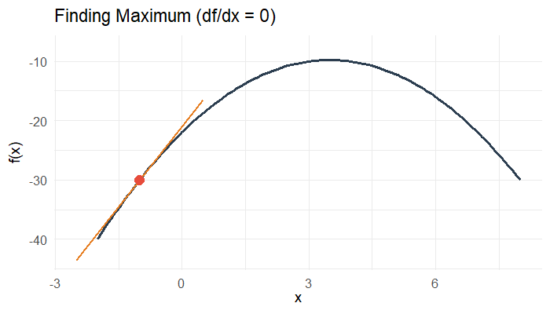

## Gradient

- Derivative in multiple dimensions

$$\frac{\partial f(x,y)}{x} = \lim_{\Delta \to 0} \frac{f(x + \Delta, y) - f(x,y)}{\Delta}.$$
- Gradient is the vector of these derivatives,

$$\nabla f(x,y) = \Big\{ \frac{\partial f(x,y)}{x}, \frac{\partial f(x,y)}{y} \Big\}$$

- Minimization/maximization is where all partial derivatives are zero.

## Hessian Matrix

- Second derivatives tell us the rate of change of the derivative.
- Identify inflection point:
  - Positive (Increasing at an increasing rate) *Minimum*
  - Negative (Increasing at a decreasing rate) *Maximum*
- Hessian is matrix of all second derivatives

$$H_f = \nabla^2 f(x,y) = \begin{bmatrix}
\frac{\partial^2 f}{\partial x^2} & \frac{\partial^2 f}{\partial x \partial y} \\
\frac{\partial^2 f}{\partial y \partial x} & \frac{\partial^2 f}{\partial y^2}
\end{bmatrix}$$

- Matrix version
  - Positive-definite means *Minimum*
  - Negative-definite means *Maximum*
- Variance is inverse of negative Hessian of log-likelihood.
- If Hessian isn’t positive-definite, can’t calculate variance.

## First RTMB Function

```r
f <- \(x){3-3*x -(x-5)^2} ## Function
df <- \(x){-3 -2*(x-5)}   ## Derivative
d2f <- \(x){-2}           ## Second Derivative

fc <- RTMB::MakeTape(f, 0)    ## Evaluates in C++
dfc <- fc$jacfun()            ## Create a derivative function
d2fc <- dfc$jacfun()          ## Create a derivative of derivative function

f(3) - fc(3)
```

```
[1] 0
```

```r
df(3) - dfc(3)
```

```
     [,1]
[1,]    0
```

```r
d2f(3) - d2fc(3)
```

```
     [,1]
[1,]    0
```

## Probability Mass Function

- Random variable $x$ is discrete
- Probability mass function $p(x)$
- Typical Functions: Binomial, Poisson, Negative Binomial

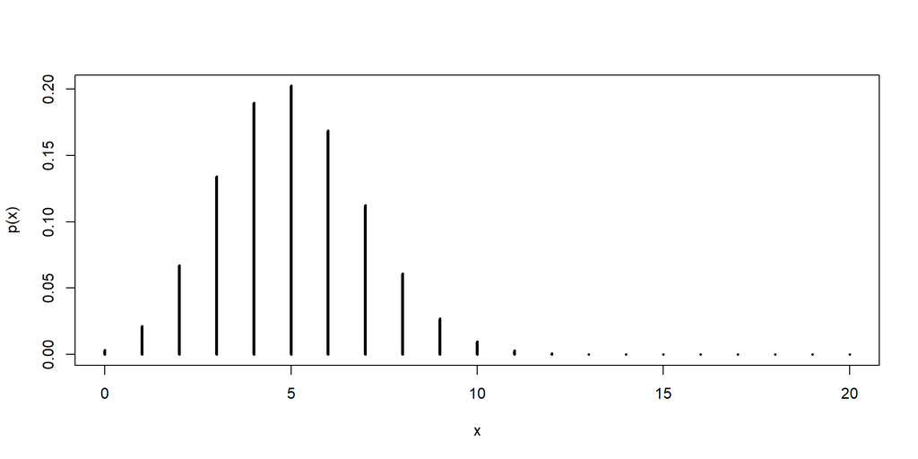

## Probability Density Function

- Random variable $x$ is continuous
- Probability density function $f(x)$
- $f(x)$ describes a density, not a probability of an event.
- Typical Functions: Normal, Student t, Gamma, Beta
- Probability defined by some area under the curve, (CDF)

$$p(x \leq 1) = \int_{-\infty}^1 f(x)dx$$

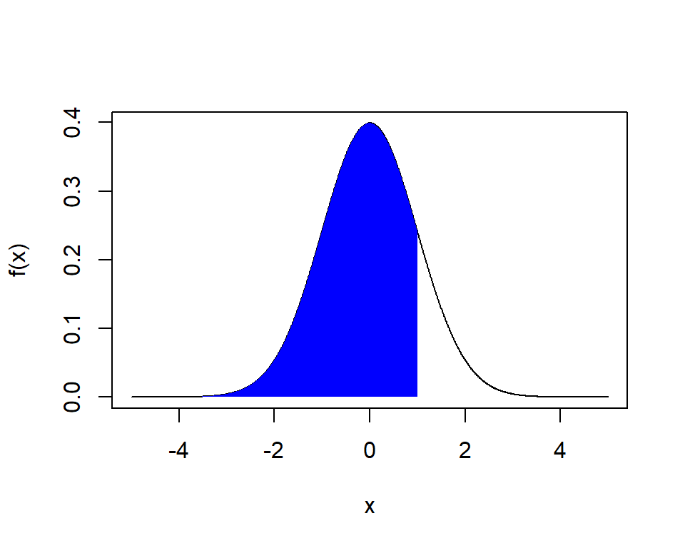

## Expectation

- Expected value of $x$ (or mean) when discrete
  $$\mathbb{E}(x) = \sum xp(x)$$

```r
  mean(rbinom(10000, size = 10, prob = 0.25))
```

```
[1] 2.497
```

```r
  sum((0:10)*dbinom(0:10, size = 10, prob = 0.25))
```

```
[1] 2.5
```

- Expected value of $x$ (or mean) when continuous
  $$\mathbb{E}(x) = \int xf(x)dx$$

```r
  mean(rgamma(10000, 1, 2))
```

```
[1] 0.5055342
```

```r
  integrate(\(x){x*dgamma(x,1,2)}, lower=0, upper=Inf)$value
```

```
[1] 0.5
```

- Sample mean
  $$\mathbb{E}(x) = \frac{\sum x_i}{n}$$

## Variance

- Variance is difference of squared expectation and expectation squared.
  $$Var(x) = \mathbb{E}(x^2) - \mathbb{E}(x)^2.$$

```r
  var(rgamma(10000, 1, 2))
```

```
[1] 0.2587823
```

```r
  integrate(\(x){x^2*dgamma(x,1,2)}, lower=0, upper=Inf)$value - (1/2)^2
```

```
[1] 0.25
```

- Sample variance
  $$Var(x) = \frac{(\sum x_i - \bar{x})^2}{n-1}$$

## Joint Density

- Some sample $\textbf{x}$, of size $n$
- Assume $x_i \sim N(\mu, \sigma)$ and all are independent.
- Then the joint density is
  $$\begin{aligned}
  f(\textbf{x}) & = f(x_1, \ldots, f_n)\\
  & = f(x_1)f(x_2) \cdots f(x_n)\\
  & = \prod_{i=1}^n f(x_i)
  \end{aligned}$$

## Conditional Density

- Some sample $\textbf{x}$, of size $n$
- Assume $x_i|u \sim N(u + \mu, \sigma)$
- $u \sim N(0, 1)$ is a random variable (e.g. random effect)
- The $x$ values are not independent!
  $$f(\textbf{x}) \neq \prod_{i=1}^n f(x_i)$$
- However, conditional on the value of $u$, they are independent,
  $$f(\textbf{x}|u) = \prod_{i=1}^n f(x_i|u)$$
- Joint density can be written as
  $$f(\textbf{x}) = \int f(\textbf{x},u)du = \int f(\textbf{x}|u)f(u)du$$

## Likelihood

- For some parameters $\boldsymbol{\theta} = \{\mu, \sigma\}$
- Likelihood is the data joint density expressed in terms of the parameters, conditional on the data.

$$L(\boldsymbol{\theta} | \textbf{x}) = \prod_{i=1}^n f(x_i)$$

- Maximum likelihood estimation – Find maximum values of parameters given the data.

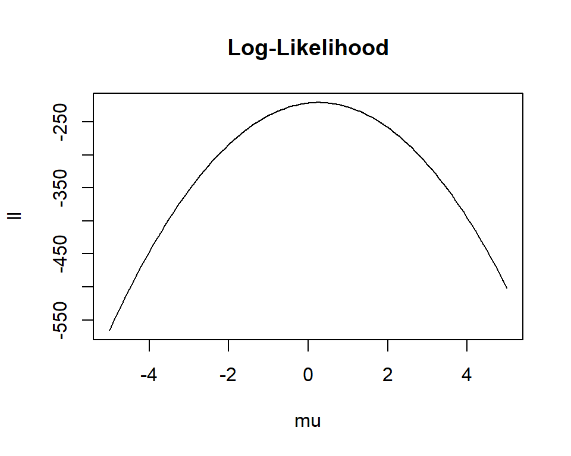

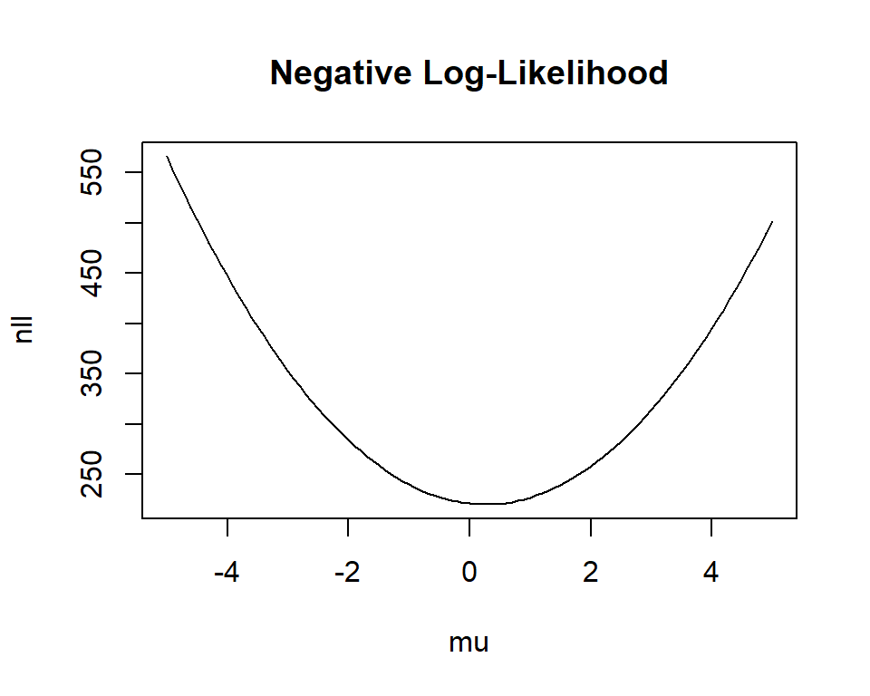

## Fitting a Likelihood in R

- Maximum of likelihood is also maximum of log-likelihood
- Maximization is the same as minimizing the negative.
- Multiplying small numbers is bad…

```r
  x <- rnorm(1000, 0, 5)
  fx <- dnorm(x, 0, 5)
  log(prod(fx))
```

```
[1] -Inf
```

```r
  sum(log(fx))
```

```
[1] -3031.56
```

- In general, we build the log-likelihood in R by summing over the log of each independent component of the likelihood.

$$\log(L(\boldsymbol{\theta}|\mathbf{x}) = \sum \log(f(x_i)).$$
- This is best done in R vectorized. Loops are generally slow, especially when nested. - In C++ loops are very fast.

```r
  x <- rnorm(1000, 0, 5)
  ll_vec <- \(a){
    lfx <- dnorm(x, 0, 5, log = TRUE)
    ll <- sum(lfx)
    ll*a
  }
  ll_loop <- \(a){
    ll <- 0
    for( i in 1:1000){
      ll <- ll + dnorm(x[i], 0, 5, log = TRUE)
    }
    ll*a
  }

  ## First taste of RTMB... :)
  ll_loopc <- RTMB::MakeTape(ll_loop, 1)

  microbenchmark::microbenchmark(
    vectorized = ll_vec(1),
    looped = ll_loop(1),
    looped_c = ll_loopc(1),
    times = 100
  )
```

```
Unit: microseconds
       expr   min     lq    mean median     uq    max neval cld
 vectorized  26.5  29.65  42.462  31.85  33.15 1044.6   100 a
     looped 434.7 472.35 541.652 543.45 604.55  724.7   100  b
   looped_c   1.1   1.40   2.848   2.10   3.00   14.0   100   c
```

## Optimization in R

- Gradient is the slope (derivative) in terms of the parameters
- Gradient based optimization uses slope to find max/min by where the function is flat (gradient = 0)
- Random start, evaluate objective function, use gradient to move to new value
- Run until at maximum/minimum (where gradient is zero)
- Examples are `optim` or `nlminb`
- If gradient not provided, then finite differences are used.

```r
set.seed(24)
x <- rnorm(100, 0.25, 2)
nll <- \(pars){
  mu <- pars[1]
  sigma <- exp(pars[2])
  -sum(dnorm(x, mu, sigma, log = TRUE))
}

optim(c(0,0), nll)
```

```
$par
[1] 0.002630714 0.634894835

$value
[1] 205.3885

$counts
function gradient
      57       NA

$convergence
[1] 0

$message
NULL
```

```r
# nlminb(c(0,0), nll)
```

## Optimization in R

- What about more than one peak? (Multimodality)
- Derivative is zero at more than one place
- Want ‘global’ maximum
- Random starting points and taking global max works
- If likelihood looks this way there are likely other things wrong
- In theory, as we get more data, the likelihood becomes more smooth and ‘peaky’

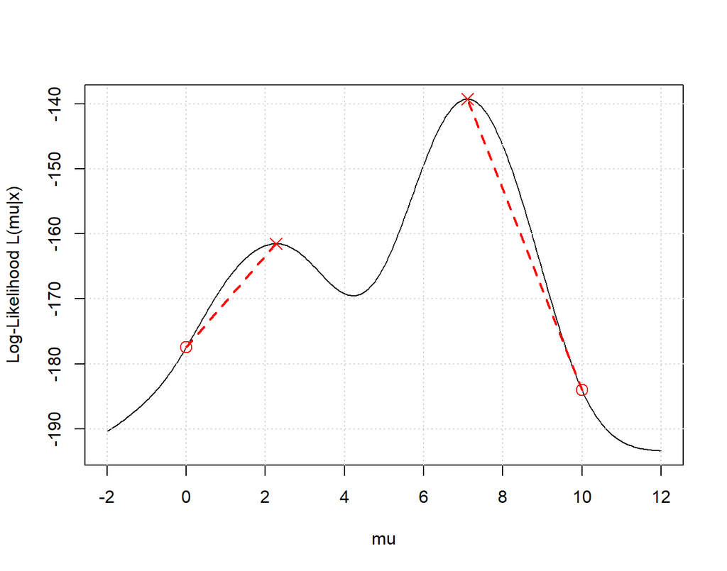

## Basic RTMB Example

```r
library(RTMB)
set.seed(42)
x <- rnorm(30, 2, 1)
negloglik <- \(theta){
  mu <- theta[1]
  sigma <- exp(theta[2])
  ans <- -sum(dnorm(x, mu, sigma, log = TRUE))
  return(ans)
}
obj <- RTMB::MakeTape(negloglik, numeric(2))
gr <- obj$jacfun()

fit <- nlminb(c(0,0), obj, obj$jacobian)
fit$par
```

```
[1] 2.0685868 0.2102072
```

## End of Module

- Take home:
  - derivatives will be important in this course
  - reminder of fundamental statistics
  - write basic likelihoods in R
  - basic numerical thoughts
  - hand wavy explanation of optimization
- Questions?
- Quick Break before a practical session